# dissipation-theory--Study-10

- Name: `dissipation-theory--Study-10.ipynb`
- Author: John A. Marohn
- Date: 2023-10-09
- Continued from: `dissipation-theory--Study-9.ipynb`
- Continued to: --
- Plot the friction $\gamma_{\perp}$ versus height $h$ expected for thin organic semiconductor sample backed by a metal.

# Preliminaries

```python
from dissipationtheory.constants import ureg
from dissipationtheory.dissipation import CantileverModelJit, SampleModel1Jit
from dissipationtheory.dissipation import theta1norm_jit, gamma_perpendicular_jit, gamma_perpendicular_approx
```

```python
import pandas as pd
import numpy as np
import matplotlib.pyplot as plt
from matplotlib.legend_handler import HandlerTuple
```

```python
THIS = 'dissipation-theory--Study-10'
```

# Study 1

The cantilever has a resonance frequency of 62 kHz, a voltage of 3 V, and an *artificially large* radius of 150 nm. It is positioned 40 + 150 = 190 nm above the surface.

Vary the semiconductor's charge density and plot the dissipation.

```python
sample1_jit = SampleModel1Jit(
    cantilever=CantileverModelJit(62.0e3, 3.,  150E-9, 190E-9),
    epsilon_s=complex(3., -0.10),
    h_s=100E-9,
    mu=1.0E-10,
    rho=1e21,
    epsilon_d=complex(1.0e6, 0.),
    z_r=190E-9)
```

Perform a first simulation where the charge density is varied.

```python
rho = ureg.Quantity(np.logspace(start=17, stop=27, num=50), '1/m^3')
```

```python
result1 = {
    'rho': rho,
    'gamma': ureg.Quantity(np.zeros_like(rho), 'pN s/m')
}

for index, rho_ in enumerate(rho):

        sample1_jit.rho = rho_.to('1/m^3').magnitude
        result1['gamma'][index] = gamma_perpendicular_jit(theta1norm_jit, sample1_jit).to('pN s/m')
```

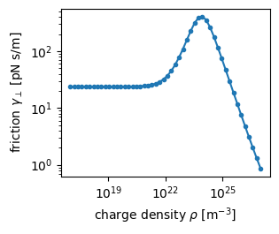

```python
fig = plt.figure(figsize=(3.25, 2.75))
plt.loglog(
    result1['rho'].to('1/m^3').magnitude,
    result1['gamma'].to('pN s/m').magnitude,
    '.-')
plt.xlabel(r'charge density $\rho$ [m$^{-3}$]')  # need a raw string here because \r is the special carriage return character
plt.ylabel('friction $\gamma_{\perp}$ [pN s/m]')
plt.tight_layout()

plt.savefig(THIS + '--Fig-1a.png', dpi=300)
plt.savefig(THIS + '--Fig-1a.pdf')

plt.show()
```

From the BLDS experiment, we suspect we are on the downside of the friction plot. So let us set the charge density to be something large. Run an example calculation ot the friction as a check; make sure the result agrees with the above graph.

```python
sample1_jit.rho = 1e24
sample1_jit.cantilever.d = 190E-9
sample1_jit.z_r = 190E-9

gamma_perpendicular_jit(theta1norm_jit, sample1_jit).to('pN s/m')
```

Magnitude

```
[398.576450684847]
```

Units

piconewton second/meter

Having set the charge density, vary the tip-sample separation. Set cantilever location to $h + R$ because the cantilever charge is located a distance $R$ away from the leading edge of the cantilever's tip.

```python
h = ureg.Quantity(np.logspace(start=np.log10(400), stop=np.log10(40), num=41), 'nm')

result2 = {
    'h': h,
    'gammaV': ureg.Quantity(np.zeros_like(h), '(pN s)/(V^2 m)')
}

R = sample1_jit.cantilever.R
for index, h_ in enumerate(h):

    sample1_jit.cantilever.d =  R + h_.to('m').magnitude
    sample1_jit.z_r = R + h_.to('m').magnitude
    norm = 1/ureg.Quantity(sample1_jit.cantilever.V_ts, 'V')**2
    result2['gammaV'][index] = (norm * gamma_perpendicular_jit(theta1norm_jit, sample1_jit)).to('(pN s)/(V^2 m)')
```

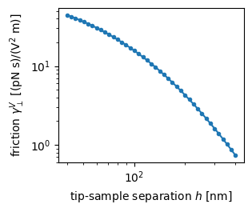

```python
fig = plt.figure(figsize=(3.25, 2.75))
plt.loglog(
    result2['h'].to('nm').magnitude,
    result2['gammaV'].to('(pN s)/(V^2 m)').magnitude,
    '.-')
plt.xlabel(r'tip-sample separation $h$ [nm]')  # need a raw string here because \r is the special carriage return character
plt.ylabel('friction $\gamma^V_{\perp}$ [(pN s)/(V$^2$ m)]')
plt.tight_layout()

plt.savefig(THIS + '--Fig-1b.png', dpi=300)
plt.savefig(THIS + '--Fig-1b.pdf')

plt.show()
```

```python
sample1_jit.print()
```

```
cantilever
==========
   cantilever freq =  62000.0 Hz
                   =  389557.48904513434 rad/s
tip-sample voltage =  3.0 V
            radius =  1.5e-07 m
            height =  1.8999999999999998e-07 m

semiconductor
=============
          epsilon (real) =  3.0
          epsilon (imag) =  -0.1
               thickness =  1e-07 m
                mobility =  1e-10 m^2/(V s)
      diffusion constant =  2.5851999850977733e-12 m^2/s
          charge density =  1e+24 m^{{-3}}
        reference height =  1.8999999999999998e-07 m
            Debye length =  1.1952706101031097e-09 m
        diffusion length =  2.5760915522619846e-09 m
effective epsilon (real) =  3.0
effective epsilon (imag) =  -4.745046916927569

dielectric
==========
 epsilon (real) =  1000000.0
 epsilon (imag) =  0.0
      thickness = infinite
```

# Study 2

Reduce the tip radius to something reasonable like 16.7 nm and repeat the above simulation.

```python
sample1_jit = SampleModel1Jit(
    cantilever=CantileverModelJit(62.0e3, 3.,  16.7E-9, 56.7E-9),
    epsilon_s=complex(3., -0.10),
    h_s=100E-9,
    mu=1.0E-10,
    rho=1e21,
    epsilon_d=complex(1.0e6, 0.),
    z_r=56.7E-9)
```

```python
result1 = {
    'rho': rho,
    'gamma': ureg.Quantity(np.zeros_like(rho), 'pN s/m')
}

for index, rho_ in enumerate(rho):

        sample1_jit.rho = rho_.to('1/m^3').magnitude
        result1['gamma'][index] = gamma_perpendicular_jit(theta1norm_jit, sample1_jit).to('pN s/m')
```

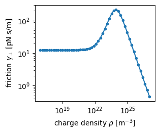

```python
fig = plt.figure(figsize=(3.25, 2.75))
plt.loglog(
    result1['rho'].to('1/m^3').magnitude,
    result1['gamma'].to('pN s/m').magnitude,
    '.-')
plt.xlabel(r'charge density $\rho$ [m$^{-3}$]')  # need a raw string here because \r is the special carriage return character
plt.ylabel('friction $\gamma_{\perp}$ [pN s/m]')
plt.tight_layout()

plt.savefig(THIS + '--Fig-2a.png', dpi=300)
plt.savefig(THIS + '--Fig-2a.pdf')

plt.show()
```

```python
sample1_jit.rho = 1e24
sample1_jit.cantilever.d = 56.7E-9
sample1_jit.z_r = 56.7E-9

gamma_perpendicular_jit(theta1norm_jit, sample1_jit).to('pN s/m')
```

Magnitude

```
[217.94059939545403]
```

Units

piconewton second/meter

```python
h = ureg.Quantity(np.logspace(start=np.log10(400), stop=np.log10(40), num=41), 'nm')

result2 = {
    'h': h,
    'gammaV': ureg.Quantity(np.zeros_like(h), '(pN s)/(V^2 m)')
}

R = sample1_jit.cantilever.R
for index, h_ in enumerate(h):

    sample1_jit.cantilever.d =  R + h_.to('m').magnitude
    sample1_jit.z_r = R + h_.to('m').magnitude
    norm = 1/ureg.Quantity(sample1_jit.cantilever.V_ts, 'V')**2
    result2['gammaV'][index] = (norm * gamma_perpendicular_jit(theta1norm_jit, sample1_jit)).to('(pN s)/(V^2 m)')
```

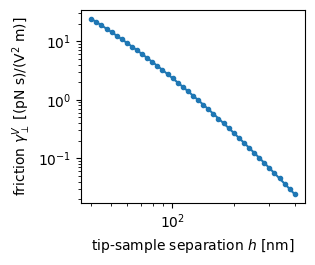

```python
fig = plt.figure(figsize=(3.25, 2.75))
plt.loglog(
    result2['h'].to('nm').magnitude,
    result2['gammaV'].to('(pN s)/(V^2 m)').magnitude,
    '.-')
plt.xlabel(r'tip-sample separation $h$ [nm]')  # need a raw string here because \r is the special carriage return character
plt.ylabel('friction $\gamma^V_{\perp}$ [(pN s)/(V$^2$ m)]')
plt.tight_layout()

plt.savefig(THIS + '--Fig-2b.png', dpi=300)
plt.savefig(THIS + '--Fig-2b.pdf')

plt.show()
```